# Mission 2 — ROC, AUC & choix de seuil

```r
source("../../utils/requirements.R")
library(titanic); library(dplyr); library(broom); library(ggplot2); library(pROC); library(janitor)
data("titanic_train")
df <- titanic_train %>%
  clean_names() %>%
  mutate(
    survived = factor(survived, levels=c(0,1), labels=c("No","Yes")),
    sex = factor(sex),
    pclass = factor(pclass),
    embarked = factor(embarked)
  ) %>%
  select(survived, pclass, sex, age, sib_sp, parch, fare, embarked) %>%
  tidyr::drop_na()
set.seed(42)
idx <- sample(seq_len(nrow(df)), size = floor(.8*nrow(df)))
train <- df[idx,]; test <- df[-idx,]
mod <- glm(survived ~ sex + pclass + age + fare, data=train, family=binomial())
```

## Objectifs

- Comprendre et **tracer** la **courbe ROC**
- Mesurer l’**AUC** et l’interpréter
- **Choisir un seuil** adapté au **coût d’erreur** (et pas seulement 0.5)
- Évaluer **sensibilité/spécificité** selon le seuil
- (Option) regarder la **calibration** simple

### 1) ROC & AUC

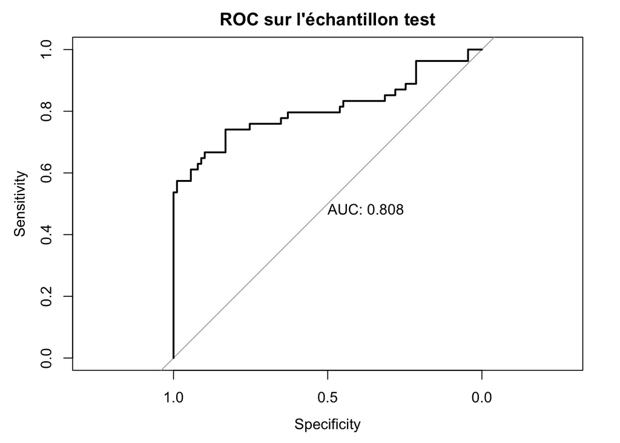

```r
prob_test <- predict(mod, newdata=test, type="response")
roc_obj <- pROC::roc(response=test$survived, predictor=prob_test, levels=c("No","Yes"))
plot(roc_obj, print.auc=TRUE, main="ROC sur l'échantillon test")
```

```r
auc_val <- pROC::auc(roc_obj); auc_val
```

```
Area under the curve: 0.8084
```

### 2) Sensibilité / Spécificité selon le seuil

[figure not shown]

```r
ths <- seq(0.1, 0.9, by=0.1)
perf <- lapply(ths, function(t){
  pred <- factor(ifelse(prob_test >= t, "Yes", "No"), levels=c("No","Yes"))
  tab <- table(Truth=test$survived, Pred=pred)
  sens <- tab["Yes","Yes"]/sum(tab[,"Yes"])
  spec <- tab["No","No"]/sum(tab[,"No"])
  acc  <- sum(diag(tab))/sum(tab)
  tibble::tibble(threshold=t, sensitivity=sens, specificity=spec, accuracy=acc)
}) %>% dplyr::bind_rows()
ggplot(perf, aes(threshold, sensitivity)) + geom_line() + geom_point() + labs(title="Sensibilité selon le seuil")
```

[figure not shown]

```r
ggplot(perf, aes(threshold, specificity)) + geom_line() + geom_point() + labs(title="Spécificité selon le seuil")
```

**Tip**

**Question d’application**  
- Si **rater un survivant** est très coûteux, vers quel **seuil** vous tournez-vous (plus bas/plus haut) ? Quelles conséquences sur la **spécificité** ?

### 3) Choix de seuil par **coûts différenciés**

```r
### 3) Choix de seuil par **coûts différenciés**
# Exemple de coûts (à adapter au contexte)
cost_fp <- 1   # coût d'un faux positif
cost_fn <- 5   # coût d'un faux négatif (plus grave)

ths <- seq(0.01, 0.99, by = 0.01)

grid <- do.call(rbind, lapply(ths, function(t) {
  pred <- factor(ifelse(prob_test >= t, "Yes", "No"), levels = c("No","Yes"))
  # Comptes robustes (même si une combinaison est absente)
  FP <- sum(test$survived == "No"  & pred == "Yes")
  FN <- sum(test$survived == "Yes" & pred == "No")
  data.frame(
    threshold = t,
    FP = FP,
    FN = FN,
    expected_cost = cost_fp * FP + cost_fn * FN
  )
}))

best_idx <- which.min(grid$expected_cost)
best_threshold <- grid$threshold[best_idx]
best_threshold
```

```
[1] 0.04
```

```r
# Performance au meilleur seuil selon ce coût
pred_best <- factor(ifelse(prob_test >= best_threshold, "Yes","No"), levels=c("No","Yes"))
tab_best <- table(Truth=test$survived, Pred=pred_best)
knitr::kable(as.data.frame.matrix(tab_best), caption = sprintf("Matrice de confusion au seuil optimal = %.2f (coûts FP=%d, FN=%d)", best_threshold, cost_fp, cost_fn))
```

Matrice de confusion au seuil optimal = 0.04 (coûts FP=1, FN=5)

|  | No | Yes |
| --- | --- | --- |
| No | 4 | 85 |
| Yes | 0 | 54 |

**Warning**

**Attention**  
- L’**AUC** **n’impose pas** un seuil ; elle juge la **discrimination** pour *tous* les seuils.  
- Le **seuil optimal dépend du contexte** : coûts d’erreurs, prévalence, contraintes opérationnelles.

### 4) (optionnel) - Calibration (aperçu simple)

```r
cuts <- quantile(prob_test, probs=seq(0,1,by=.1))
grp <- cut(prob_test, breaks=unique(cuts), include.lowest=TRUE)
calib <- test %>% mutate(prob=prob_test, grp=grp) %>% group_by(grp) %>%
  summarise(obs_rate=mean(survived=="Yes"), pred_mean=mean(prob), .groups="drop")
knitr::kable(calib, caption="Calibration par déciles : moyenne prédite vs proportion observée")
```

Calibration par déciles : moyenne prédite vs proportion observée

| grp | obs_rate | pred_mean |
| --- | --- | --- |
| [0.0137,0.0603] | 0.1333333 | 0.0426319 |
| (0.0603,0.0746] | 0.3571429 | 0.0674806 |
| (0.0746,0.0958] | 0.1428571 | 0.0833150 |
| (0.0958,0.113] | 0.1428571 | 0.1036356 |
| (0.113,0.219] | 0.1333333 | 0.1685682 |
| (0.219,0.381] | 0.0714286 | 0.2740320 |
| (0.381,0.595] | 0.3571429 | 0.5072802 |
| (0.595,0.776] | 0.4285714 | 0.6794945 |
| (0.776,0.875] | 1.0000000 | 0.8320176 |
| (0.875,0.956] | 1.0000000 | 0.9265891 |

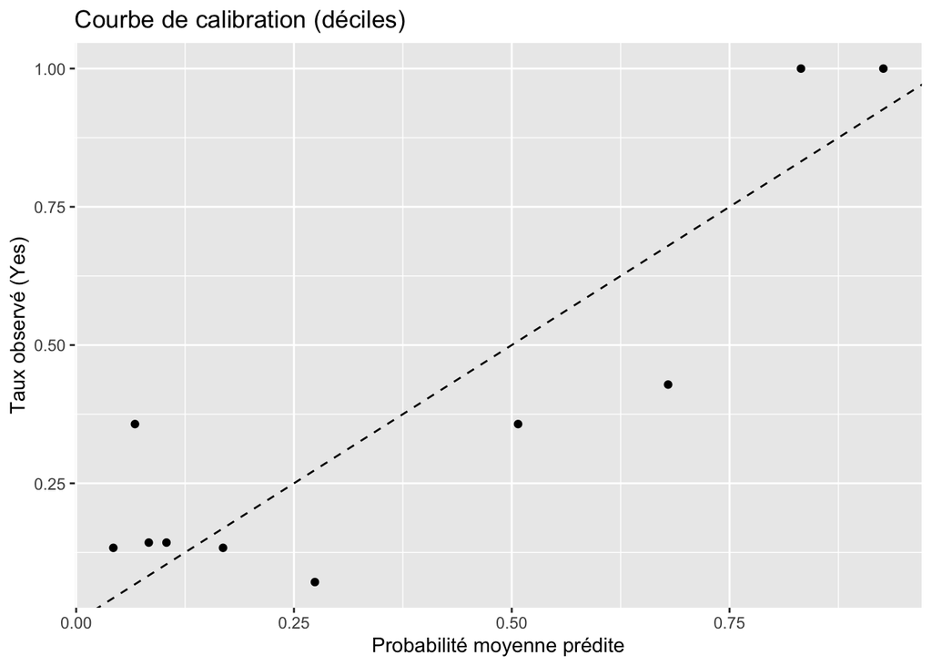

```r
ggplot(calib, aes(pred_mean, obs_rate)) + geom_point() + geom_abline(slope=1, intercept=0, linetype=2) +
  labs(x="Probabilité moyenne prédite", y="Taux observé (Yes)", title="Courbe de calibration (déciles)")
```

**Note**

**Réflexion**  
- Si les points sont **au-dessus** de la diagonale, vos probabilités sont-elles **sous-** ou **sur-**estimées ?

## Questions (différentes de M1)

1. Donnez une **interprétation** de l’AUC en termes de paires (survivant vs non-survivant).
2. Expliquez pourquoi **changer le seuil** peut **augmenter la sensibilité** tout en **diminuant la spécificité**.
3. Avec un coût **FN > FP**, justifiez un **seuil < 0.5** même si l’accuracy baisse.
4. Que révèle la **calibration** de vos probabilités ?

## Points de discussion (retour groupe)

- Pourquoi l’AUC **ne suffit pas** à choisir un seuil ?
- Comment fixer les **coûts** en pratique (métier, impact) ?
- Quelles limites de la ROC quand les classes sont **déséquilibrées** ? (courbe PR utile)